# Project 1 - Mercedes-Benz Greener Manufacturing

### 1. Data Exploration

###### 1.1 Examine the dimension and preview the training dataset

```python
import pandas as pd

df_train = pd.read_csv('train.csv')
df_train.shape
```

```
(4209, 378)
```

```python
pd.options.display.max_columns = 999
df_train.head()
```

|  | ID | y | X0 | X1 | X2 | X3 | X4 | X5 | X6 | X8 | X10 | X11 | X12 | X13 | X14 | X15 | X16 | X17 | X18 | X19 | X20 | X21 | X22 | X23 | X24 | X26 | X27 | X28 | X29 | … |
| --- | --- | --- | --- | --- | --- | --- | --- | --- | --- | --- | --- | --- | --- | --- | --- | --- | --- | --- | --- | --- | --- | --- | --- | --- | --- | --- | --- | --- | --- | --- |
| 0 | 0 | 130.81 | k | v | at | a | d | u | j | o | 0 | 0 | 0 | 1 | 0 | 0 | 0 | 0 | 1 | 0 | 0 | 1 | 0 | 0 | 0 | 0 | 0 | 0 | 0 | … |
| 1 | 6 | 88.53 | k | t | av | e | d | y | l | o | 0 | 0 | 0 | 0 | 0 | 0 | 0 | 0 | 1 | 0 | 0 | 0 | 0 | 0 | 0 | 0 | 1 | 0 | 0 | … |
| 2 | 7 | 76.26 | az | w | n | c | d | x | j | x | 0 | 0 | 0 | 0 | 0 | 0 | 0 | 1 | 0 | 0 | 0 | 0 | 0 | 0 | 0 | 0 | 1 | 1 | 1 | … |
| 3 | 9 | 80.62 | az | t | n | f | d | x | l | e | 0 | 0 | 0 | 0 | 0 | 0 | 0 | 0 | 0 | 0 | 0 | 0 | 0 | 0 | 0 | 0 | 1 | 1 | 1 | … |
| 4 | 13 | 78.02 | az | v | n | f | d | h | d | n | 0 | 0 | 0 | 0 | 0 | 0 | 0 | 0 | 0 | 0 | 0 | 0 | 0 | 0 | 0 | 0 | 1 | 1 | 1 | … |

###### 1.2 Take out the y from the training dataset and examine the rest of data as features

```python
df_y_train = df_train['y']
df_x_train = df_train.drop(columns = ['y'])

df_x_train.dtypes.value_counts()
```

```
int64     369
object      8
dtype: int64
```

###### There are 369 integer-type features and 8 categorical features.

###### 1.3 . First explore the integer-type features

```python
df_x_train.describe()
```

|  | ID | X10 | X11 | X12 | X13 | X14 | X15 | X16 | X17 | X18 | X19 | X20 | X21 | X22 | X23 | X24 | X26 | X27 | X28 | X29 | X30 | X31 | X32 | X33 | X34 | X35 | X36 | X37 | X38 | … |
| --- | --- | --- | --- | --- | --- | --- | --- | --- | --- | --- | --- | --- | --- | --- | --- | --- | --- | --- | --- | --- | --- | --- | --- | --- | --- | --- | --- | --- | --- | --- |
| count | 4209.000000 | 4209.000000 | 4209.0 | 4209.000000 | 4209.000000 | 4209.000000 | 4209.000000 | 4209.000000 | 4209.000000 | 4209.000000 | 4209.000000 | 4209.000000 | 4209.000000 | 4209.000000 | 4209.000000 | 4209.000000 | 4209.000000 | 4209.000000 | 4209.000000 | 4209.000000 | 4209.000000 | 4209.000000 | 4209.000000 | 4209.000000 | 4209.000000 | 4209.000000 | 4209.000000 | 4209.000000 | 4209.000000 | … |
| mean | 4205.960798 | 0.013305 | 0.0 | 0.075077 | 0.057971 | 0.428130 | 0.000475 | 0.002613 | 0.007603 | 0.007840 | 0.099549 | 0.142789 | 0.002613 | 0.086957 | 0.020670 | 0.001901 | 0.004989 | 0.682585 | 0.032549 | 0.043003 | 0.004514 | 0.232359 | 0.011167 | 0.000238 | 0.005464 | 0.232359 | 0.004514 | 0.232359 | 0.033262 | … |
| std | 2437.608688 | 0.114590 | 0.0 | 0.263547 | 0.233716 | 0.494867 | 0.021796 | 0.051061 | 0.086872 | 0.088208 | 0.299433 | 0.349899 | 0.051061 | 0.281805 | 0.142294 | 0.043561 | 0.070467 | 0.465526 | 0.177475 | 0.202888 | 0.067043 | 0.422387 | 0.105093 | 0.015414 | 0.073729 | 0.422387 | 0.067043 | 0.422387 | 0.179341 | … |
| min | 0.000000 | 0.000000 | 0.0 | 0.000000 | 0.000000 | 0.000000 | 0.000000 | 0.000000 | 0.000000 | 0.000000 | 0.000000 | 0.000000 | 0.000000 | 0.000000 | 0.000000 | 0.000000 | 0.000000 | 0.000000 | 0.000000 | 0.000000 | 0.000000 | 0.000000 | 0.000000 | 0.000000 | 0.000000 | 0.000000 | 0.000000 | 0.000000 | 0.000000 | … |
| 25% | 2095.000000 | 0.000000 | 0.0 | 0.000000 | 0.000000 | 0.000000 | 0.000000 | 0.000000 | 0.000000 | 0.000000 | 0.000000 | 0.000000 | 0.000000 | 0.000000 | 0.000000 | 0.000000 | 0.000000 | 0.000000 | 0.000000 | 0.000000 | 0.000000 | 0.000000 | 0.000000 | 0.000000 | 0.000000 | 0.000000 | 0.000000 | 0.000000 | 0.000000 | … |
| 50% | 4220.000000 | 0.000000 | 0.0 | 0.000000 | 0.000000 | 0.000000 | 0.000000 | 0.000000 | 0.000000 | 0.000000 | 0.000000 | 0.000000 | 0.000000 | 0.000000 | 0.000000 | 0.000000 | 0.000000 | 1.000000 | 0.000000 | 0.000000 | 0.000000 | 0.000000 | 0.000000 | 0.000000 | 0.000000 | 0.000000 | 0.000000 | 0.000000 | 0.000000 | … |
| 75% | 6314.000000 | 0.000000 | 0.0 | 0.000000 | 0.000000 | 1.000000 | 0.000000 | 0.000000 | 0.000000 | 0.000000 | 0.000000 | 0.000000 | 0.000000 | 0.000000 | 0.000000 | 0.000000 | 0.000000 | 1.000000 | 0.000000 | 0.000000 | 0.000000 | 0.000000 | 0.000000 | 0.000000 | 0.000000 | 0.000000 | 0.000000 | 0.000000 | 0.000000 | … |
| max | 8417.000000 | 1.000000 | 0.0 | 1.000000 | 1.000000 | 1.000000 | 1.000000 | 1.000000 | 1.000000 | 1.000000 | 1.000000 | 1.000000 | 1.000000 | 1.000000 | 1.000000 | 1.000000 | 1.000000 | 1.000000 | 1.000000 | 1.000000 | 1.000000 | 1.000000 | 1.000000 | 1.000000 | 1.000000 | 1.000000 | 1.000000 | 1.000000 | 1.000000 | … |

```python
df_description = df_x_train.describe().T.reset_index()
df_description.groupby(['min', 'max']).count()
```

| min | max | index | count | mean | std | 25% | 50% | 75% |
| --- | --- | --- | --- | --- | --- | --- | --- | --- |
| 0.0 | 0.0 | 12 | 12 | 12 | 12 | 12 | 12 | 12 |
|  | 1.0 | 356 | 356 | 356 | 356 | 356 | 356 | 356 |
|  | 8417.0 | 1 | 1 | 1 | 1 | 1 | 1 | 1 |

###### Out of the 369 integer-type features, 12 are all 0, 1 is the 'ID' and the remaining 356 are binary with min value 0 and max value 1.

###### 1.4 Identify columns that has no variation in values

```python
list_features_single_value = df_description[df_description['std'] == 0]['index'].to_list()
print("Features with single value:", list_features_single_value)
```

```
Features with single value: ['X11', 'X93', 'X107', 'X233', 'X235', 'X268', 'X289', 'X290', 'X293', 'X297', 'X330', 'X347']
```

###### 1.5 Next explore the 8 categorical variables

```python
df_dtypes = df_x_train.dtypes
list_features_categorical = df_dtypes[df_dtypes == 'object'].index.tolist()
print("Features with categorical value:", list_features_categorical)
```

```
Features with categorical value: ['X0', 'X1', 'X2', 'X3', 'X4', 'X5', 'X6', 'X8']
```

```python
import numpy as np

list_x_unique_value_train = []
list_x_unique_count_train = []
for col in list_features_categorical:
    list_x_unique_value_train.append(df_x_train[col].unique())
    list_x_unique_count_train.append(df_x_train[col].unique().size)
print("Unique value counts for categorical cols in training set:", list_x_unique_count_train)
```

```
Unique value counts for categorical cols in training set: [47, 27, 44, 7, 4, 29, 12, 25]
```

###### The unique value counts serve as quick reference to cross check corresponding test dataset

###### 1.6 Explore the test dataset

```python
df_test = pd.read_csv('test.csv')
df_test.shape
```

```
(4209, 377)
```

```python
df_test.head()
```

|  | ID | X0 | X1 | X2 | X3 | X4 | X5 | X6 | X8 | X10 | X11 | X12 | X13 | X14 | X15 | X16 | X17 | X18 | X19 | X20 | X21 | X22 | X23 | X24 | X26 | X27 | X28 | X29 | X30 | … |
| --- | --- | --- | --- | --- | --- | --- | --- | --- | --- | --- | --- | --- | --- | --- | --- | --- | --- | --- | --- | --- | --- | --- | --- | --- | --- | --- | --- | --- | --- | --- |
| 0 | 1 | az | v | n | f | d | t | a | w | 0 | 0 | 0 | 0 | 0 | 0 | 0 | 0 | 0 | 0 | 0 | 0 | 0 | 0 | 0 | 0 | 1 | 1 | 1 | 0 | … |
| 1 | 2 | t | b | ai | a | d | b | g | y | 0 | 0 | 0 | 0 | 0 | 0 | 0 | 0 | 0 | 1 | 0 | 0 | 0 | 0 | 0 | 0 | 1 | 0 | 0 | 0 | … |
| 2 | 3 | az | v | as | f | d | a | j | j | 0 | 0 | 0 | 0 | 1 | 0 | 0 | 0 | 0 | 0 | 0 | 0 | 0 | 0 | 0 | 0 | 1 | 0 | 1 | 0 | … |
| 3 | 4 | az | l | n | f | d | z | l | n | 0 | 0 | 0 | 0 | 0 | 0 | 0 | 0 | 0 | 0 | 0 | 0 | 0 | 0 | 0 | 0 | 1 | 1 | 1 | 0 | … |
| 4 | 5 | w | s | as | c | d | y | i | m | 0 | 0 | 0 | 0 | 1 | 0 | 0 | 0 | 0 | 0 | 0 | 0 | 0 | 0 | 0 | 0 | 1 | 0 | 0 | 0 | … |

```python
df_test.dtypes.value_counts()
```

```
int64     369
object      8
dtype: int64
```

###### Test dataset has a similar set of features as the training dataset.

###### 1.7 Analyze the categorical features in test dataset in more details

```python
list_x_unique_value_test = []
list_x_unique_count_test = []
for col in list_features_categorical:
    list_x_unique_value_test.append(df_test[col].unique())
    list_x_unique_count_test.append(df_test[col].unique().size)
print("Unique value counts for categorical cols in test set:", list_x_unique_count_test)
```

```
Unique value counts for categorical cols in test set: [49, 27, 45, 7, 4, 32, 12, 25]
```

```python
list_x_unique_value_diff = []
list_x_unique_count_diff = []
for col in range(0, len(list_features_categorical)):
    list_diff =  list(set(list_x_unique_value_test[col]) - set(list_x_unique_value_train[col]))
    list_x_unique_value_diff.append(list_diff)
    list_x_unique_count_diff.append(len(list_diff))
print("Unique value counts in test categorical cols but not in those in training dataset:", list_x_unique_count_diff)
```

```
Unique value counts in test categorical cols but not in those in training dataset: [6, 0, 6, 0, 0, 4, 0, 0]
```

```python
df_test_diff = df_test[df_test['X0'].isin(list_x_unique_value_diff[0])
                      | df_test['X2'].isin(list_x_unique_value_diff[2])
                      | df_test['X5'].isin(list_x_unique_value_diff[5])]
df_test_diff.shape
```

```
(24, 377)
```

###### The test dataset has a few categorical features containing values that are not present in the training dataset, which may result in inaccurate prediction if these are import features in the trained model. Although there are only 24 records, will try to find a solution in the analysis later.

### 2. Data Wrangling

###### 2.1 If for any column(s), the variance is equal to zero, then you need to remove those variable(s)

```python
list_cols_to_use = list(set(df_train.columns) - set(list_features_single_value) - set('y'))
df_train = df_train[list_cols_to_use]
df_train.shape
```

```
(4209, 365)
```

```python
df_test = df_test[list_cols_to_use]
df_test.shape
```

```
(4209, 365)
```

###### 2.2 Check for null values for test and train sets

```python
df_train.isnull().values.any()
```

```
False
```

```python
df_test.isnull().values.any()
```

```
False
```

###### No null values are observed in both datasets.

###### 2.3 Apply label encoder

```python
mapper = lambda x: sum([ord(digit) for digit in x])
for col in list_features_categorical:
        df_train[col] = df_train[col].apply(mapper)
        df_test[col] = df_test[col].apply(mapper)
```

```python
df_train[list_features_categorical].head()
```

|  | X0 | X1 | X2 | X3 | X4 | X5 | X6 | X8 |
| --- | --- | --- | --- | --- | --- | --- | --- | --- |
| 0 | 107 | 118 | 213 | 97 | 100 | 117 | 106 | 111 |
| 1 | 107 | 116 | 215 | 101 | 100 | 121 | 108 | 111 |
| 2 | 219 | 119 | 110 | 99 | 100 | 120 | 106 | 120 |
| 3 | 219 | 116 | 110 | 102 | 100 | 120 | 108 | 101 |
| 4 | 219 | 118 | 110 | 102 | 100 | 104 | 100 | 110 |

```python
df_test[list_features_categorical].head()
```

|  | X0 | X1 | X2 | X3 | X4 | X5 | X6 | X8 |
| --- | --- | --- | --- | --- | --- | --- | --- | --- |
| 0 | 219 | 118 | 110 | 102 | 100 | 116 | 97 | 119 |
| 1 | 116 | 98 | 202 | 97 | 100 | 98 | 103 | 121 |
| 2 | 219 | 118 | 212 | 102 | 100 | 97 | 106 | 106 |
| 3 | 219 | 108 | 110 | 102 | 100 | 122 | 108 | 110 |
| 4 | 119 | 115 | 212 | 99 | 100 | 121 | 105 | 109 |

###### 2.4 Perform dimensionality reduction

```python
df_x_train = df_train.drop(columns = ['ID'])
df_x_test = df_test.drop(columns = ['ID'])
```

```python
from sklearn.decomposition import PCA
from sklearn.preprocessing import StandardScaler
sc = StandardScaler()
arr_x_train_scaled = sc.fit_transform(df_x_train)
arr_x_test_scaled = sc.transform(df_x_test)
pca = PCA().fit(arr_x_train_scaled)
```

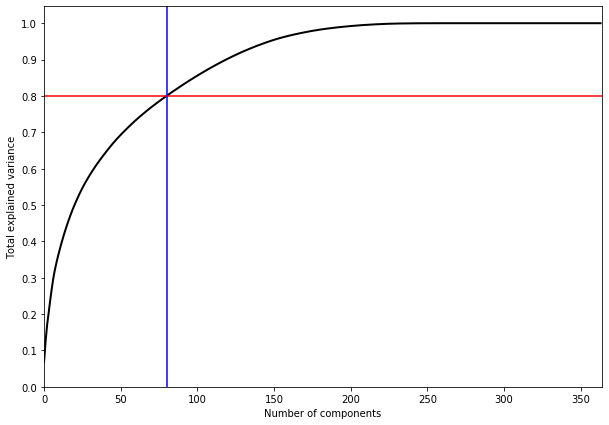

```python
import matplotlib.pyplot as plt
import numpy as np
# Visualize Variance by new Dimensions
plt.figure(figsize=(10,7))

plt.plot(np.cumsum(pca.explained_variance_ratio_), color='k', lw=2)

plt.xlabel('Number of components')
plt.ylabel('Total explained variance')

plt.xlim(0, 364)
plt.yticks(np.arange(0, 1.1, 0.1))

plt.axhline(0.8, c='r')
plt.axvline(80, c='b')

plt.show()
```

###### Targeting to explain 80% variance, corresponding number of components is around 80.

###### 2.5 Apply PCA with 80 components

```python
pca = PCA(n_components = 80)
arr_x_train_pca = pca.fit_transform(arr_x_train_scaled)
arr_x_test_pca = pca.transform(arr_x_test_scaled)
```

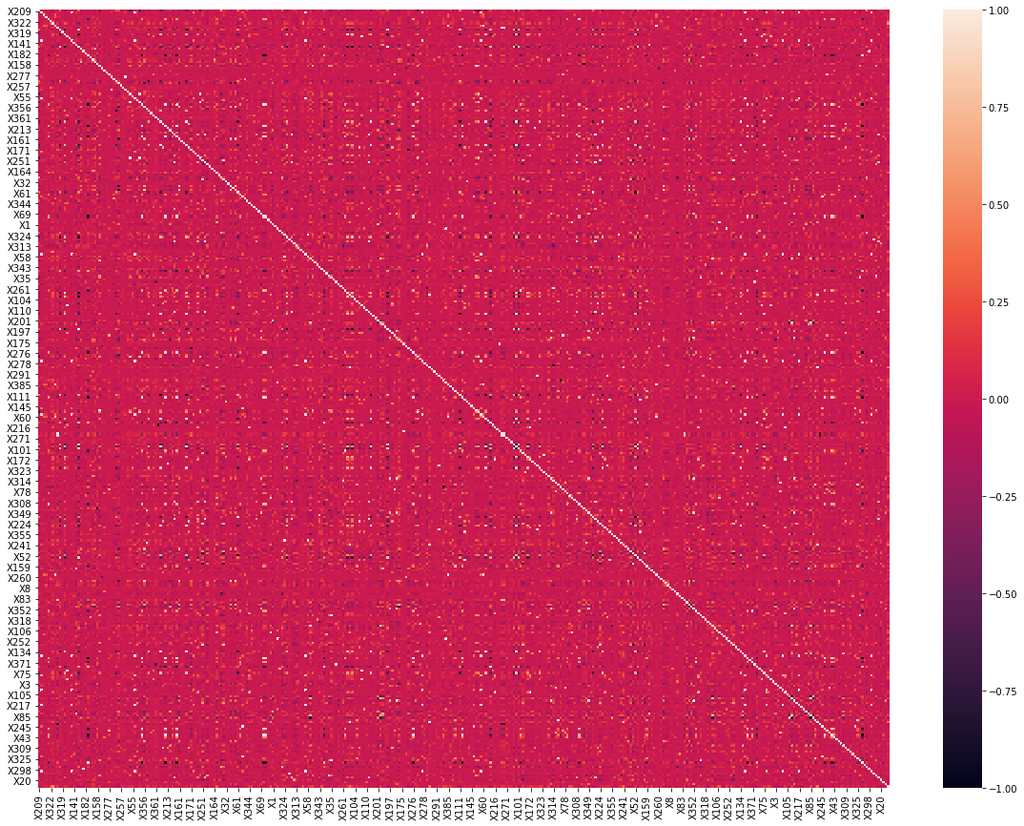

```python
import seaborn as sns
plt.figure(figsize = (20,15))
sns.heatmap(df_x_train.corr())
plt.show()
```

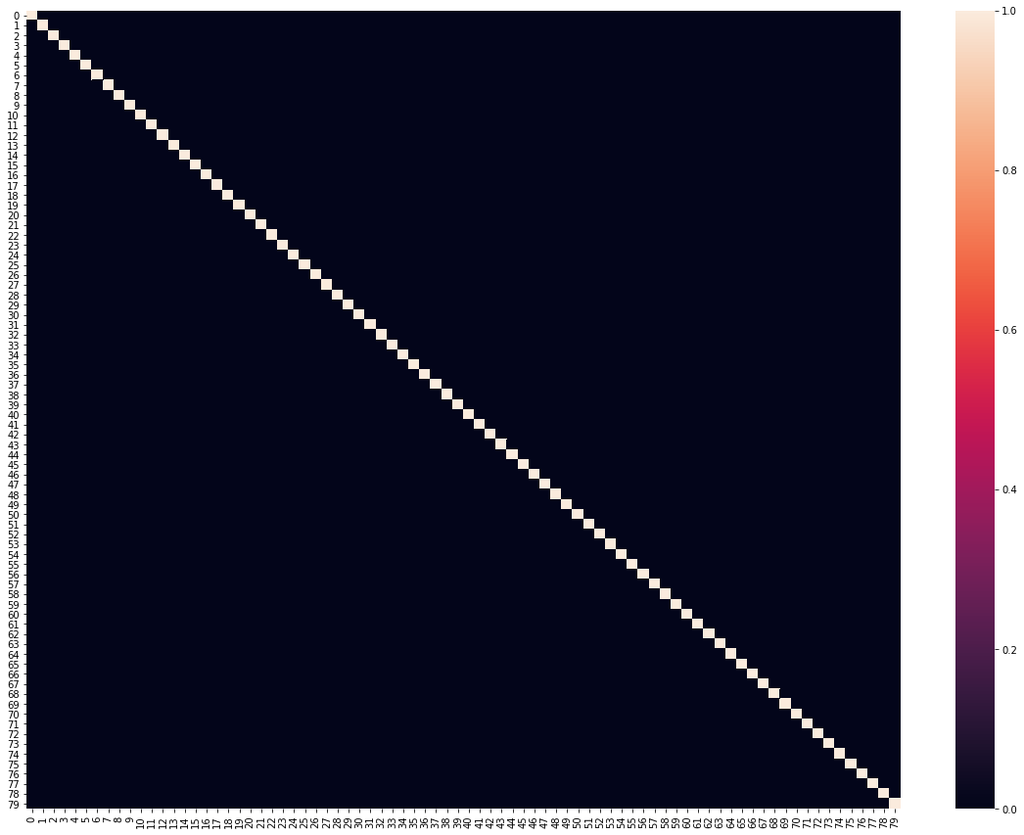

```python
plt.figure(figsize=(20,15))
sns.heatmap(pd.DataFrame(arr_x_train_pca).corr())
plt.show()
```

###### As observed the reduced dimension have removed correlations.

### 3 Model Training

###### 3.1 Train the model using XGBoost by utilizing the data with reduced dimensions

```python
import xgboost as xgb
from sklearn.metrics import r2_score
from sklearn.model_selection import train_test_split

x_train, x_valid, y_train, y_valid = train_test_split(arr_x_train_pca, df_y_train, test_size = 0.2, random_state = 4242)

dm_train = xgb.DMatrix(x_train, label = y_train)
dm_valid = xgb.DMatrix(x_valid, label = y_valid)

xgb_params = {
    'objective': 'reg:squarederror',
    'eta': 0.02,
    'max_depth': 4,
    #'subsample': 0.7,
    #'colsample_bytree': 0.7,
    #'silent': 1
}

def xgb_r2_score(preds, dtrain):
    labels = dtrain.get_label()
    return 'r2', r2_score(labels, preds)

watchlist = [(dm_train, 'train'), (dm_valid, 'valid')]

model_pca = xgb.train(xgb_params, dm_train, 1000, watchlist, early_stopping_rounds=50, feval=xgb_r2_score, maximize=True, verbose_eval=10)
```

```python
dm_test = xgb.DMatrix(arr_x_test_pca)
arr_test = model_pca.predict(dm_test)

df_y_predicted_pca = pd.DataFrame()
df_y_predicted_pca['ID'] = df_test['ID']
df_y_predicted_pca['y'] = arr_test
df_y_predicted_pca.to_csv('Results xgb PCA.csv', index =False)
df_y_predicted_pca.shape
```

```
(4209, 2)
```

```python
df_y_predicted_pca.head(10)
```

|  | ID | y |
| --- | --- | --- |
| 0 | 1 | 95.639626 |
| 1 | 2 | 121.487991 |
| 2 | 3 | 89.139145 |
| 3 | 4 | 82.314011 |
| 4 | 5 | 105.993973 |
| 5 | 8 | 92.708496 |
| 6 | 10 | 112.273170 |
| 7 | 11 | 96.299622 |
| 8 | 12 | 115.300148 |
| 9 | 14 | 95.282356 |

###### Using reduced-dimension features limits the ability to understand features that are important to the model.

###### 3.2 Create a model without PCA to understand the key features

```python
x_train, x_valid, y_train, y_valid = train_test_split(df_x_train, df_y_train, test_size = 0.2, random_state = 4242)

dm_train = xgb.DMatrix(x_train, label=y_train)
dm_valid = xgb.DMatrix(x_valid, label=y_valid)

xgb_params = {
    'objective': 'reg:squarederror',
    'eta': 0.02,
    'max_depth': 4,
    #'subsample': 0.7,
    #'colsample_bytree': 0.7,
    #'silent': 1
}

def xgb_r2_score(preds, dtrain):
    labels = dtrain.get_label()
    return 'r2', r2_score(labels, preds)

watchlist = [(dm_train, 'train'), (dm_valid, 'valid')]

model_full = xgb.train(xgb_params, dm_train, 1000, watchlist, early_stopping_rounds=50, feval=xgb_r2_score, maximize=True, verbose_eval=10)
```

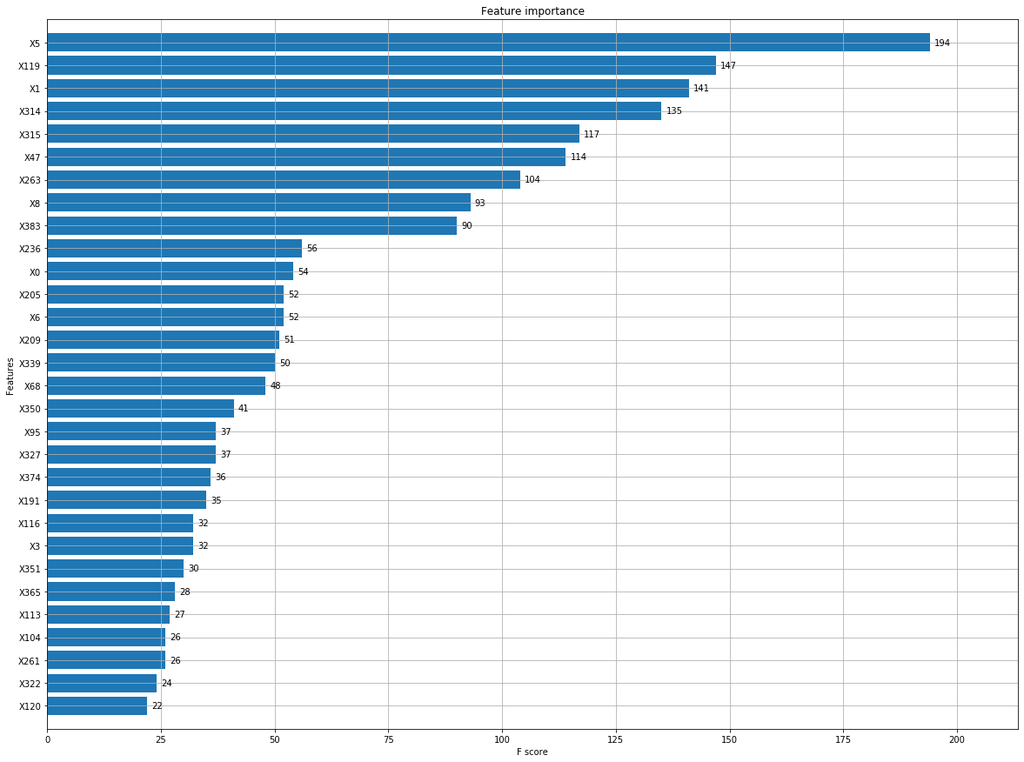

```python
fig, ax = plt.subplots(figsize = (20,15))
xgb.plot_importance(model_full, max_num_features = 30, height = 0.8, ax = ax)
plt.show()
```

###### Features such as X5 are seen critical. As pointed out in section 1.7, X5 in test data has value not present in training dataset.

###### 3.3 Create another model by removing these features to predict for records pointed out in section 1.7

```python
list_features_to_remove = ['X0', 'X2', 'X5']
df_x_train_reduced = df_x_train.drop(columns = list_features_to_remove)

x_train, x_valid, y_train, y_valid = train_test_split(df_x_train_reduced, df_y_train, test_size = 0.2, random_state = 4242)

dm_train = xgb.DMatrix(x_train, label = y_train)
dm_valid = xgb.DMatrix(x_valid, label = y_valid)

xgb_params = {
    'objective': 'reg:squarederror',
    'eta': 0.02,
    'max_depth': 4,
    #'subsample': 0.7,
    #'colsample_bytree': 0.7,
    #'silent': 1
}

def xgb_r2_score(preds, dtrain):
    labels = dtrain.get_label()
    return 'r2', r2_score(labels, preds)

watchlist = [(dm_train, 'train'), (dm_valid, 'valid')]

model_reduced = xgb.train(xgb_params, dm_train, 1000, watchlist, early_stopping_rounds=50, feval=xgb_r2_score, maximize=True, verbose_eval=10)
```

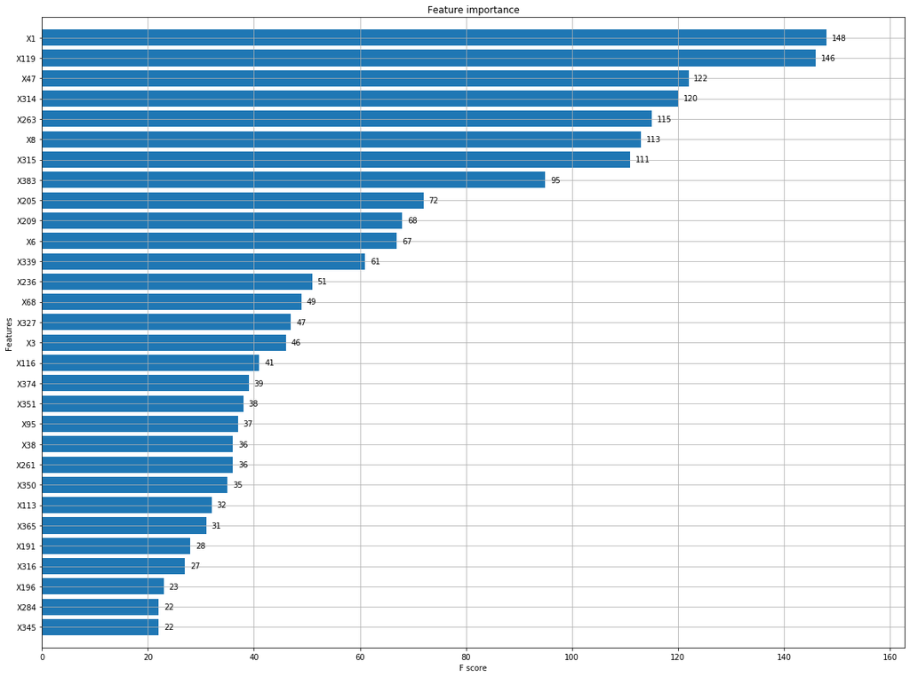

```python
fig, ax = plt.subplots(figsize = (20,15))
xgb.plot_importance(model_reduced, max_num_features = 30, height = 0.8, ax = ax)
plt.show()
```

###### 3.4 Using model created in section 3.2 to predict for records that do NOT have the issue pointed out in section 1.7

```python
df_x_test_part1 = df_test[~df_test['ID'].isin(df_test_diff['ID'])]
dm_test = xgb.DMatrix(df_x_test_part1.drop(columns = ['ID']))
arr_test_part1 = model_full.predict(dm_test)

df_y_predicted_part1 = pd.DataFrame()
df_y_predicted_part1['ID'] = df_x_test_part1['ID']
df_y_predicted_part1['y'] = arr_test_part1
df_y_predicted_part1.shape
```

```
(4185, 2)
```

```python
df_y_predicted_part1.head(10)
```

|  | ID | y |
| --- | --- | --- |
| 4 | 5 | 111.189957 |
| 5 | 8 | 92.616425 |
| 6 | 10 | 110.918404 |
| 7 | 11 | 93.660889 |
| 8 | 12 | 115.803413 |
| 9 | 14 | 94.189919 |
| 10 | 15 | 115.666718 |
| 11 | 16 | 103.965233 |
| 12 | 17 | 96.042122 |
| 13 | 19 | 93.874397 |

###### 3.5 Using model created in section 3.3 to predict for records that are facing the issue pointed out in section 1.7

```python
df_x_test_part2 = df_test[df_test['ID'].isin(df_test_diff['ID'])].drop(columns = list_features_to_remove)
dm_test = xgb.DMatrix(df_x_test_part2.drop(columns = ['ID']))
arr_test_part2 = model_reduced.predict(dm_test)

df_y_predicted_part2 = pd.DataFrame()
df_y_predicted_part2['ID'] = df_x_test_part2['ID']
df_y_predicted_part2['y'] = arr_test_part2

df_y_predicted_part2.shape
```

```
(24, 2)
```

```python
df_y_predicted_part2.head(10)
```

|  | ID | y |
| --- | --- | --- |
| 0 | 1 | 92.920601 |
| 1 | 2 | 109.715805 |
| 2 | 3 | 93.196274 |
| 3 | 4 | 77.817390 |
| 88 | 163 | 94.333359 |
| 153 | 289 | 93.545013 |
| 203 | 393 | 112.055695 |
| 311 | 624 | 146.385696 |
| 1943 | 3893 | 111.818863 |
| 1999 | 4010 | 112.613342 |

###### 3.6 Combine the results from section 3.4 and 3.5 to as the full test predicted result set

```python
df_y_predicted = df_y_predicted_part1.append(df_y_predicted_part2)
df_y_predicted.sort_values(by = ['ID'], inplace = True)
df_y_predicted.to_csv('Results xgb split.csv', index = False)
df_y_predicted.shape
```

```
(4209, 2)
```

```python
df_y_predicted.head(10)
```

|  | ID | y |
| --- | --- | --- |
| 0 | 1 | 92.920601 |
| 1 | 2 | 109.715805 |
| 2 | 3 | 93.196274 |
| 3 | 4 | 77.817390 |
| 4 | 5 | 111.189957 |
| 5 | 8 | 92.616425 |
| 6 | 10 | 110.918404 |
| 7 | 11 | 93.660889 |
| 8 | 12 | 115.803413 |
| 9 | 14 | 94.189919 |